# Recan: R package for analysis of recombination events in viral genomes

4 January 2021

# Summary

`recan` is an R version of Python library that allows recombination event analysis through construction and exploration of similarity plots based on genetic distances between nucleotide sequences (Babin 2020). The R version of `recan` is based on `Bio3D` and `Plotly` libraries. Package included two functions: `seqSim` and `scanSeqSim`. Both functions require a sequence alignment in fasta format as an input. Output is a dataframe with sequences similarities illustrated by a single `plotly` plot or a list of plots for every pair of sequences with highlighted region of putative recombination.

# Statement of need

Nowadays the pandemic of SARS-COV-2 virus attracts attention to viral diseases and the evolution of its agents. Detection of recombinations is more reproducible to perform in an automatic pipeline, rather than use GUI (Etherington, Dicks, and Roberts 2005; Lole et al. 1999). As R language (R Core Team 2018) is more widely used by biologists I ported `recan` package from Python to R.

#The user can change parameters for seqSim function: the sequence that is used for similarity calculation, the sliding window size, the window shift, and a region of interest (to plot only an area where breakpoints occur).

#But if there is a lot of sequences in alignment it is difficult to find exact recombination. For nice looking picture it is required to exclude unnecessary lines.

# Testing and verification

To test the package, we used the same four sets of viral genomes from the article with a description of Python version of `recan` (Babin 2020). The resulting `seqSim` method execution time with the window size = 400 and shift parameters = 200 showed in table 1. Both R packages are faster than Python version.

Table 1. Benchmarking of python and R version of recan package

|  | number of sequences | bp | recan python | recan R | seqcombo R |
| --- | --- | --- | --- | --- | --- |
| HIV | 25 | 3135 | 437 ms ± 7.74 ms | 152 ms ± 13.9 ms | 116 ms ± 16.6 ms |
| HCV | 23 | 9431 | 579 ms ± 58.7 ms | 437 ms ± 63.5 ms | 132.8 ms ± 16.7 ms |
| Norovirus | 19 | 3366 | 648 ms ± 44.2 ms | 98 ms ± 6,42 ms | 94.1 ms ± 19.7 ms |
| LSDV | 14 | 150511 | 3.55 s ± 239 ms | 2.63 s ± 570 ms | 391.4 ms ± 40.2 ms |

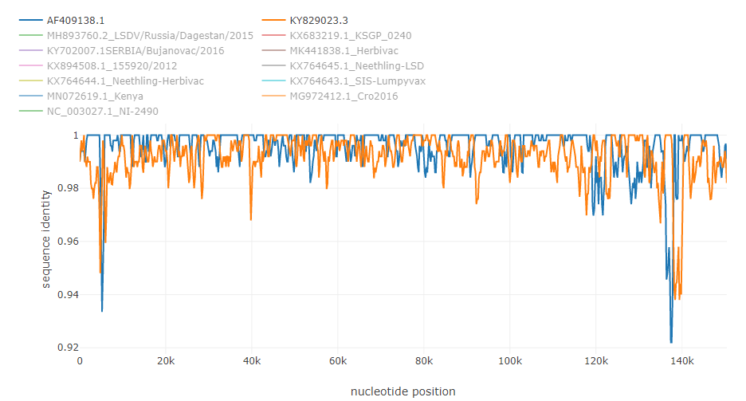

[figure not shown]

# Availability and implementation

Recan is supported on Linux, MacOS and Windows. The package can be installed by `devtools` R package using command

```
install.packages("devtools")
library(devtools)
devtools::install_github("vasily-pavelko/recan")
```

The source code, guide and datasets are available on the GitHub repository (https://github.com/vasily-pavelko/recan).

# Acknowledgement

The author thanks Alexander Sprygin for editing the manuscript and providing LSDV data.

# References

Babin, Yuriy. 2020. “Recan: Python Tool for Analysis of Recombination Events in Viral Genomes.” *Journal of Open Source Software* 5 (49): 2014. https://doi.org/10.21105/joss.02014.

Etherington, Graham J., Jo Dicks, and Ian N. Roberts. 2005. “Recombination Analysis Tool (RAT): A Program for the High-Throughput Detection of Recombination.” *Bioinformatics (Oxford, England)* 21 (3): 278–81. https://doi.org/10.1093/bioinformatics/bth500.

Lole, K. S., R. C. Bollinger, R. S. Paranjape, D. Gadkari, S. S. Kulkarni, N. G. Novak, R. Ingersoll, H. W. Sheppard, and S. C. Ray. 1999. “Full-Length Human Immunodeficiency Virus Type 1 Genomes from Subtype C-Infected Seroconverters in India, with Evidence of Intersubtype Recombination.” *Journal of Virology* 73 (1): 152–60. https://doi.org/10.1128/JVI.73.1.152-160.1999.

Paraskevis, D, E G Kostaki, G Magiorkinis, G Panayiotakopoulos, G Sourvinos, and S Tsiodras. 2020. “Full-Genome Evolutionary Analysis of the Novel Corona Virus (2019-nCoV) Rejects the Hypothesis of Emergence as a Result of a Recent Recombination Event.” *Infection, Genetics and Evolution : Journal of Molecular Epidemiology and Evolutionary Genetics in Infectious Diseases* 79 (April): 104212–2. https://doi.org/10.1016/j.meegid.2020.104212.

R Core Team. 2018. *R: A Language and Environment for Statistical Computing*. Vienna, Austria: R Foundation for Statistical Computing. https://www.R-project.org/.

Yu, Guangchuang. 2021. “Seqcombo: Visualization Tool for Sequence Recombination and Reassortment.” Bioconductor version: Release (3.12). https://doi.org/10.18129/B9.bioc.seqcombo.